# Spatial transcriptomics data analysis using Rmarkdown

Jiaxin Yang

06/14/2021

# 1 Introduction

## 1.1 Source

This pipeline is mainly used “Giotto: a toolbox for integrative analysis and visualization of spatial expression data” published on ~Genome Biology~ and its Github guideline.

## 1.2 Abstract

~Spatial transcriptomic~ and proteomic technologies have provided new opportunities to investigate cells in their native microenvironment. Here we present Giotto, a comprehensive and open-source toolbox for spatial data analysis and visualization. The analysis module provides end-to-end analysis by implementing a wide range of algorithms for characterizing tissue composition, spatial expression patterns, and cellular interactions. Furthermore, single-cell RNAseq data can be integrated for spatial cell-type enrichment analysis. The visualization module allows users to interactively visualize analysis outputs and imaging features. To demonstrate its general applicability, we apply Giotto to a wide range of datasets encompassing diverse technologies and platforms.

## 1.3 Data format of spatial transcriptomics

- A matrix of gene expression per spot
- A matirx of spot coordination
- image (optional)

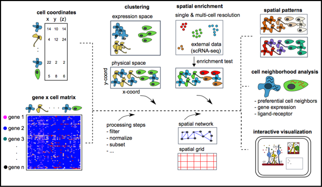

## 1.4 Pipeline Directory

1. Create a Giotto object
2. Process and filter a Giotto object
3. Dimension reduction
4. Cluster cells or spots
5. Identify differentially expressed genes
6. Annotate clusters
7. Cell-type enrichment or deconvolution per spot
8. Create a Spatial grid or Network
9. Find genes with a spatially coherent gene expression pattern
10. Identify genes that are spatially co-expressed
11. Explore spatial domains with HMRF
12. Calculate spatial cell-cell interaction enrichment
13. Find cell-cell interaction changed genes (ICG)
14. Identify enriched or depleted ligand-receptor interactions in hetero and homo-typic cell interactions

## 1.5 Setup Step

# 2 1. Create a Giotto object